# Entropy

- Entropy
- Conditional entropy
- Mutual information
- Cross entropy
- Relative entropy (KL divergence (Kullback-Leibler))

# Entropy

The entropy of a descrete random variable X is

$$H(X)=E[-\log_{2}P(X)]=-\sum_{i=1}^n P(x_i)\log_2 P(x_i)$$

$P$ is the probability mass function of a random variable X

## What does entropy mean?

```python
import numpy as np
def coin_toss_entropy(coin_prob):
    # 0<=coin_prob<=1
    f = lambda x: x*np.log2(x)
    return -(f(coin_prob)+f(1-coin_prob))
```

```
Max entropy is 1.0 where p=0.5
```

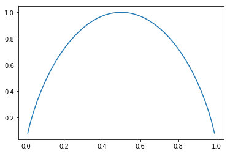

```python
%matplotlib inline
import matplotlib.pyplot as plt

p = np.linspace(0.01,0.99,99)
entropy_p = coin_toss_entropy(p)
M = np.amax(entropy_p)
index = np.argmax(entropy_p)
print('Max entropy is {} where p={}'.format(M, p[index]))
plt.plot(p, entropy_p)
```

As above, when you toss a fair coin (p=0.5), you get least information (max entropy). Entropy is **how much information you get.** (Zero is max information.)

## Why entropy needs log? (additive property)

In short, logarithm is to make it growing linearly with system size and "behaving like information".

The entropy of tossing a fair coin is $$-\sum_{i=1}^2 \frac{1}{2} \log_2 \frac{1}{2}=1$$

Tossing a fair coin **two times** is random choice number from 1 to 4.

The entropy of random choicing number 1 to 4 is $$-\sum_{i=1}^4 \frac{1}{4} \log_2 \frac{1}{4}=2$$

just 2 times of tossing a fair coin.

[What is the role of the logarithm in Shannon's entropy?](https://stats.stackexchange.com/questions/87182/what-is-the-role-of-the-logarithm-in-shannons-entropy)

# Conditional entropy

$$ \begin{align} H(X|Y)&=E[-log_2 P(X|Y)] \\ &=-\sum_{i,j} P(x_i, y_j)\log_2 P(x_i|y_j)\\ &=-\sum_{i,j} P(x_i, y_j)\log_2 \frac{P(x_i,y_j)}{P(y_j)} \\ &=-\sum_{i,j} P(x_i, y_j)\log_2 P(x_i,y_j) + \sum_{i,j} P(x_i, y_j)\log_2 P(y_j)\\ &=H(X,Y)-H(Y) \end{align}$$

The entropy of X given Y is equal to the joint entropy of X&Y minus the entropy of Y

# Mutual information

$$I(X,Y)=\sum_{i,j}P(x_i,y_j)log_2 \frac{P(x_i,y_j)}{P(x_i)P(y_j)}$$

## Property

1. Non-negative, i.e. $I(X,Y)\ge 0$
2. Symmetric $I(X,Y)=I(Y,X)$
3. $H(X,Y) \\ = H(X)-H(X|Y) \\ = H(Y)-H(Y|X) \\ = H(X)+H(Y)-H(X,Y) \\ = H(X,Y)-H(Y|X)-H(X|Y)$

## Example

$X$, $Y$ are both bernoulli random variable with success probability $p_x$, $p_y$. $$ \begin{align} I(X,Y)&=P(X=0,Y=0)\log_2 \frac{P(X=0,Y=0)}{P(X=0)P(Y=0)}\\ &+P(X=1,Y=0)\log_2 \frac{P(X=1,Y=0)}{P(X=1)P(Y=0)}\\ &+P(X=0,Y=1)\log_2 \frac{P(X=0,Y=1)}{P(X=0)P(Y=1)}\\ &+P(X=1,Y=1)\log_2 \frac{P(X=1,Y=1)}{P(X=1)P(Y=1)} \end{align}$$

- If $P(X=1, Y=1)>P(X=1)P(Y=1)$ (positive correlated), then the first term & forth term are bigger than zero.
- If $P(X=1, Y=0)>P(X=1)P(Y=0)$ (negative correlated), then the second term & third term are smaller than zero.

# Cross entropy

P & Q are two discrete probability distribution

$$\begin{align} H(P,Q)&=E_P[-\log Q]\\ &=-\sum_i P(i) \log Q(i)\\ &=-\sum_i P(i) \log \frac{Q(i)}{P(i)} - \sum_i P(i) \log P(i)\\ &=D_{KL}(P||Q) + H(P) \end{align}$$

# Relative entropy (KL divergence)

P & Q are two discrete probability distribution $$ \begin{align} D_{KL}(P||Q)&=-\sum_i P(i)\log \frac{Q(i)}{P(i)}\\ &=-\sum_i P(i)\log Q(i) + \sum_i P(i)\log P(i) \end{align}$$

- If P & Q are identical distribution almost everywhere, $D_{KL}(P||Q)=0$
- $D_{KL}(P||Q) \ge 0$ ([Gibb's inequality](https://en.wikipedia.org/wiki/Gibbs%27_inequality))

If P is a known distribution (true label distribution), and $D_{KL}(P||Q) = H(P,Q) - H(P)$, minimize cross-entropy is equivalent to minimize KL divergence.

Reference

- [Wikipedia Entropy](https://en.wikipedia.org/wiki/Mutual_information)
- [What is the role of the logarithm in Shannon's entropy?](https://stats.stackexchange.com/questions/87182/what-is-the-role-of-the-logarithm-in-shannons-entropy)
- [Kullback–Leibler divergence](https://en.wikipedia.org/wiki/Kullback–Leibler_divergence)
- [Cross entropy method](https://en.wikipedia.org/wiki/Cross-entropy_method)